# Examples showing importance of zero-stability

[AMath 586, Spring Quarter 2019](http://staff.washington.edu/rjl/classes/am586s2019/) at the University of Washington. For other notebooks, see Index.html or the [Index of all notebooks on Github](https://github.com/rjleveque/amath586s2019/blob/master/notebooks/Index.html).

For Forward Euler and Midpoint, we observe that the error grows with time, but over a fixed time interval it converges to zero with $\Delta t = k$. These methods are not only consistent but also zero-stable. Finally we test a method that is consistent but fails to be zero-stable and see that the method does not converge.

```python
%matplotlib inline
```

In this notebook we use some widgets from the [ipywidgets](https://ipywidgets.readthedocs.io/en/stable/) module:

```python
from pylab import *
from ipywidgets import interact, IntSlider
```

Define a function to make plots to use with each method tested:

```python
def make_plots(t,U,method_name):
    Utrue = exp(t)
    E = U - Utrue  # error
    Emax = abs(E).max()
    dt = t[1] - t[0]

    figure(figsize=(11,5))
    subplot(1,2,1)
    plot(t, Utrue, 'k-', label='True solution')
    plot(t, U, 'b-o', label='Computed')
    legend(loc='upper left')
    ylim(0,10)
    title('%s with dt = %.6f' % (method_name,dt))
    subplot(1,2,2)
    plot(t, E, 'r-o')
    title('Maximum |Error| = %.6f' % Emax)
```

## Forward Euler

First we test the Forward Euler method.

```python
def ForwardEuler(nsteps):
    t0 = 0.;  tfinal = 2.
    t = linspace(t0, tfinal, nsteps+1)
    dt = t[1] - t[0]

    # Array for computed solution
    # give it two rows so each column is solution at one time,
    # since function f(u) = A*u is matrix-vector multiplication

    U = empty(nsteps+1)
    U.fill(nan)
    U[0] = 1.  # initial value
    for n in range(0,nsteps):
        U[n+1] = U[n] + dt * U[n]

    make_plots(t,U,'Forward Euler')
```

If you call this with different values of `nsteps` you should see that the solution converges as `nsteps` increases.

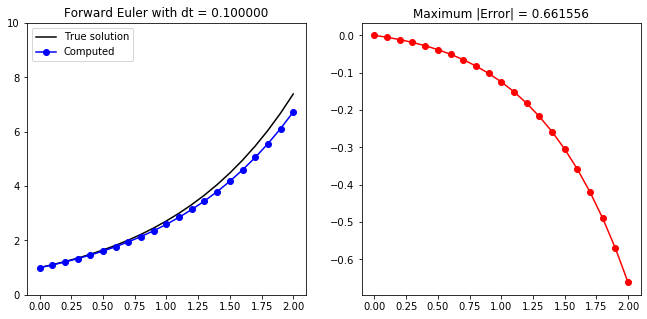

```python
ForwardEuler(20)
```

This can be simplified with a widget that allows easily changing `nsteps` over a suitable range:

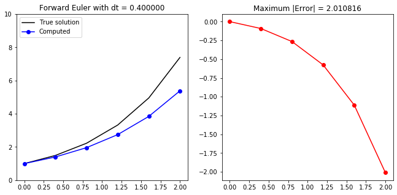

```python
interact(ForwardEuler, nsteps=IntSlider(min=5,max=25,step=5,value=5));
```

Note that the absolute value of the error grows exponentially in time. Nonetheless, over any fixed time interval such as the $0 \leq t \leq 2$ used here, the error decays to zero over the entire interval as `nsteps` grows (i.e. as $\Delta t \rightarrow 0$).

## Midpoint method

Recall that the 2-point midpoint method $U^{n+2} = U^n + 2 k f(U^{n+1})$ is second order accurate. Here's an implementation on the test problem $u' = u$:

```python
def Midpoint(nsteps):
    t0 = 0.;  tfinal = 2.
    t = linspace(t0, tfinal, nsteps+1)
    dt = t[1] - t[0]

    U = empty(nsteps+1)
    U.fill(nan)
    U[0] = 1.       # initial value
    U[1] = exp(dt)  # exact solution at t_1

    for n in range(0,nsteps-1):
        U[n+2] = U[n] + 2*dt * U[n+1]

    make_plots(t,U,'Midpoint')
```

Since Midpoint is also zero-stable, we see convergence as we increase `nsteps`. The error still grows exponentially with time but with a multiplicative constant that goes to zero like $\Delta t^2$:

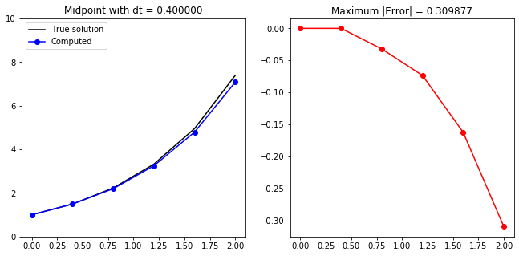

```python
interact(Midpoint, nsteps=IntSlider(min=5,max=25,step=5,value=5));
```

## An exponentially bad method

Now consider the method given in Example 6.2 on page 143 of the text, $$ U^{n+2} - 3U^{n+1} + 2U^n = -k f(U^n). $$ This 2-step linear multistep method is formally first order accurate, with trunction error $\tau^n = \frac 1 2 k u''(t_n) + O(k^2)$, and hence is *consistent.*

Here's an implementation:

```python
def ExpBadMethod(nsteps):
    t0 = 0.;  tfinal = 2.
    t = linspace(t0, tfinal, nsteps+1)
    dt = t[1] - t[0]

    # Array for computed solution
    # give it two rows so each column is solution at one time,
    # since function f(u) = A*u is matrix-vector multiplication

    U = empty(nsteps+1)
    U.fill(nan)
    U[0] = 1.       # initial value
    U[1] = exp(dt)  # exact solution at t_1

    for n in range(0,nsteps-1):
        U[n+2] = 3*U[n+1] - 2*U[n] - dt * U[n]

    make_plots(t,U,'Exponentially Bad Method')
```

Although the method is consistent However, it **fails to be zero-stable**. As a result, increasing `nsteps` does not lead to better results.

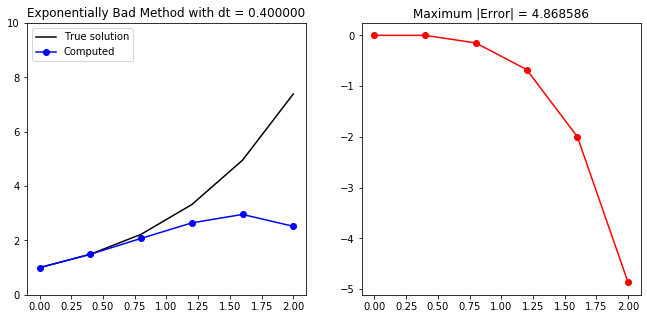

```python
interact(ExpBadMethod, nsteps=IntSlider(min=5,max=25,step=5,value=5));
```

Note that the error actually looks better for the first few time steps as $k$ is decreased. But now the error grows exponentially **in the number of steps taken**. This is very different from growing expoentially in time, since it means we do not converge as we decrease the time step over a fixed time interval, in which case `nsteps` grows.

## A linearly bad method

```python
def LinearlyBadMethod(nsteps):
    t0 = 0.;  tfinal = 2.
    t = linspace(t0, tfinal, nsteps+1)
    dt = t[1] - t[0]

    # Array for computed solution
    # give it two rows so each column is solution at one time,
    # since function f(u) = A*u is matrix-vector multiplication

    U = empty(nsteps+1)
    U.fill(nan)
    U[0] = 1.       # initial value
    U[1] = exp(dt)  # exact solution at t_1

    for n in range(0,nsteps-1):
        U[n+2] = (2*U[n+1] - U[n] - 0.5*dt * U[n]) / (1 - 0.5*dt)

    make_plots(t,U,'Linearly Bad Method')
```

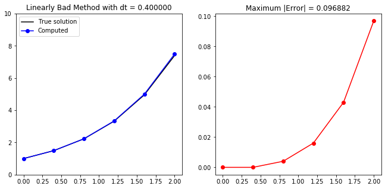

```python
interact(LinearlyBadMethod, nsteps=IntSlider(min=5,max=25,step=5,value=5));
```

This seems to be converging fine. But recall that to be *convergent* the method has to converge for any choice of starting data satisfying $U^1 \rightarrow \eta = 1$ as $k \rightarrow 0$. Here's what happens if we choose $U^1 = 1 + k/2$:

```python
def LinearlyBadMethod(nsteps):
    t0 = 0.;  tfinal = 2.
    t = linspace(t0, tfinal, nsteps+1)
    dt = t[1] - t[0]

    # Array for computed solution
    # give it two rows so each column is solution at one time,
    # since function f(u) = A*u is matrix-vector multiplication

    U = empty(nsteps+1)
    U.fill(nan)
    U[0] = 1.       # initial value
    U[1] = 1. + 0.5*dt #exp(dt)  # exact solution at t_1

    for n in range(0,nsteps-1):
        U[n+2] = (2*U[n+1] - U[n] - 0.5*dt * U[n]) / (1 - 0.5*dt)

    make_plots(t,U,'Linearly Bad Method')
```

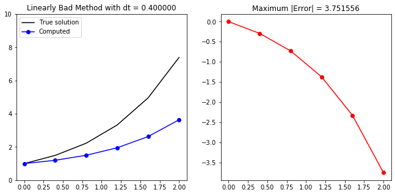

```python
interact(LinearlyBadMethod, nsteps=IntSlider(min=5,max=25,step=5,value=5));
```

Can you figure out what function this converges to?